# Análise de Dados no Melhoramento Genético de Pinus

Neste documento estão os scripts para as análises abordadas no capítulo “Análise de Dados no Melhoramento Genético de Pinus”.

# Pacotes necessários

```r
require(tidyverse)
require(asreml)
require(gghighlight)
require(ComplexHeatmap)
require(RColorBrewer)
require(ggrepel)
```

# 1. Análise individual (somente um ambiente)

## Carregando o conjunto de dados

Para realizar as análises individuais, utilizaremos somente o primeiro ambiente do conjunto de dados disponibilizados.

```r
data = read.table("EstCov.txt", header = T)

data_e1 = data %>% filter(amb == "E1") %>% select(gen, rept,y)
data_e1$gen = as.factor(data_e1$gen)
data_e1$rept = as.factor(data_e1$rept)
```

O experimento consiste em 15 tratamentos delineados em 10 blocos completos casualizados. Perceba a presença de dados perdidos (NA) no conjunto de dados. Isso não será problema para a execução da análise.

| Genótipo | Repetição | Variável |
| --- | --- | --- |
| C001 | 1 | 12.80 |
| C002 | 1 | 17.20 |
| C003 | 1 | 12.90 |
| C004 | 1 | 15.20 |
| C005 | 1 | 10.90 |
| C006 | 1 | 13.60 |
| C007 | 1 | 13.05 |
| C008 | 1 | 11.62 |
| C009 | 1 | 13.60 |
| C010 | 1 | 15.18 |
| C011 | 1 | 14.87 |
| C012 | 1 | NA |
| C013 | 1 | 14.58 |
| C014 | 1 | 10.50 |
| C015 | 1 | NA |
| C001 | 2 | 12.20 |
| C002 | 2 | 15.60 |
| C003 | 2 | 13.20 |
| C004 | 2 | 13.20 |
| C005 | 2 | 17.30 |
| C006 | 2 | 16.30 |
| C007 | 2 | 5.79 |
| C008 | 2 | 9.55 |
| C009 | 2 | 15.00 |
| C010 | 2 | 16.23 |
| C011 | 2 | 15.98 |
| C012 | 2 | 15.50 |
| C013 | 2 | 12.73 |
| C014 | 2 | 11.00 |
| C015 | 2 | 10.80 |

[output cut: 120 more lines]

## Modelo para análise dos dados

```r
m = asreml(fixed = y ~ rept,
            random = ~ gen,
            data = data_e1)
summary(m)$varcomp
```

|  | Componente | Erro-Padrão | Z-Ratio |
| --- | --- | --- | --- |
| $\sigma^2_g$ | 1.716713 | 0.8094269 | 2.120899 |
| $\sigma^2_e$ | 3.421822 | 0.4815159 | 7.106353 |

## Teste de significância: Likelihood ratio test (LRT)

Uma vez construído o modelo, é necessário determinar a significância do efeito de tratamentos. Isto é realizado utilizando o teste de deviance ou Likelihood Ratio Test (LRT). Para isto, devemos construir o modelo reduzido, isto é, sem efeito a ser testado. Com o modelo reduzido em mãos, o próprio ASReml encarrega-se de calcular o LRT utilizando a função “lrt”.

```r
mr = asreml(fixed = y ~ rept,
            data = data_e1)

lrt(m,mr)
```

```
## Likelihood ratio test(s) assuming nested random models.
## (See Self & Liang, 1987)
##
##      df LR-statistic Pr(Chisq)
## m/mr  1       23.979  4.87e-07 ***
## ---
## Signif. codes:  0 '***' 0.001 '**' 0.01 '*' 0.05 '.' 0.1 ' ' 1
```

Veja que o p-valor [Pr(Chisq)] é menor que 0.05, portanto o efeito em teste é significativo.

## Acurácia e herdabilidade

Uma vez aferida a significância, podemos calcular alguns parâmetros genéticos, como a acurácia e a herdabilidade. Para isto, utilizaremos as seguintes fórmulas:

- Acurácia [(Mrode, 2014)](https://cabidigitallibrary.org/doi/book/10.1079/9781780643915.0000)

$$r =
\sqrt{1-\frac{PEV}{\sigma^2_g}}$$
em que PEV é a variância do erro de predição, obtida da diagonal da matriz de coeficientes da equação de modelos mistos

- Herdabilidade individual

$$H^2 = \frac{\sigma^2_g}{\sigma^2_g +
\sigma^2_e}$$

- Herdabilidade média (fórmula padrão)

$$H^2_p = \frac{\sigma^2_g}{\sigma^2_g +
\frac{\sigma^2_e}{r}}$$
em que r é o número de repetições

- Herdabilidade média [(Cullis et al., 2006)](https://link.springer.com/article/10.1198/108571106X154443)

$$H^2_c = 1-
\frac{\overline{V}(\Delta)}{2\sigma^2_g}$$
em que $\overline{V}(\Delta)$ é a variância média da diferença entre dois BLUPs

Para estimar $r$ e $H_c$, utilizaremos a função “predict” do ASReml. Esta função também servirá para obtenção dos BLUPs

```r
predm_sed = predict(m,"gen", sed = T)
predm_vcov = predict(m, "gen", vcov = T)

PEV = mean(diag(predm_vcov$vcov))
Acurácia = sqrt(1-(PEV/summary(m)$varcomp[grep("gen",rownames(summary(m)$varcomp)),1]))

Herdabilidade_ind = summary(m)$varcomp[grep("gen",rownames(summary(m)$varcomp)),1] /
  (sum(summary(m)$varcomp[,1]))

Herdabilidade_med_pad = summary(m)$varcomp[grep("gen",rownames(summary(m)$varcomp)),1] /
  (summary(m)$varcomp[grep("gen",rownames(summary(m)$varcomp)),1] +
     (summary(m)$varcomp[grep("R",rownames(summary(m)$varcomp)),1]/10))

MVdelta = mean((predm_sed$sed^2)[upper.tri(predm_sed$sed^2, diag = F)])
Herdabilidade_med_cullis = 1-(MVdelta)/
  (2*summary(m)$varcomp[grep("gen",rownames(summary(m)$varcomp)),1])
```

| Parâmetro | Valor |
| --- | --- |
| r | 0.8937149 |
| $H^2$ | 0.3340860 |
| $H^2_p$ | 0.8338030 |
| $H^2_c$ | 0.8020476 |

Veja que $H^2_p$ e $H^2_c$ são diferentes, ainda que ambos indiquem a herdabilidade média no banco de dados. Isto ocorre devido ao desbalanceamento, que, no exemplo acima, é devido à perda de dados. $H^2_p$ é uma fórmula proposta para quando os dados são balanceados e, por vezes, pode distorcer o valor real da herdabilidade média. Além de $H^2_c$, existem outras alternativas que podem ser utilizadas quando os dados são desbalanceados. O leitor pode encontrá-las em [Schmidt et al. (2019a)](https://doi.org/10.2135/cropsci2018.06.0376) e [Schmidt et al. (2019b)](https://doi.org/10.1534/genetics.119.302134).

## BLUPs

Ainda utilizando a função “predict”, obteremos os BLUPs, ou valores genotípicos, dos tratamentos em análise. Com eles, realizaremos a seleção e calcularemos os ganhos genéticos estimados:

$$Ganho = \frac{BLUP_s - \mu}{\mu} \times
100$$
em que $BLUP_s$ é a média dos BLUPs dos genótipos selecionados e $\mu$ é a média do experimento. No exemplo, selecionamos os cinco melhores tratamentos.

```r
predm_sed = predict(m,"gen", sed = T)
predm_vcov = predict(m, "gen", vcov = T)

BLUP = predm_sed$pvals

BLUP = BLUP %>% arrange(desc(predicted.value))

BLUPs = BLUP[1:5,]

Ganho = (mean(BLUPs$predicted.value) - mean(BLUP$predicted.value)) /
  mean(BLUP$predicted.value) * 100
```

| Genótipo | BLUP | Erro padrão |
| --- | --- | --- |
| C011 | 15.36731 | 0.5946647 |
| C002 | 15.13002 | 0.5642512 |
| C010 | 14.83315 | 0.5377889 |
| C003 | 14.32643 | 0.5645627 |
| C009 | 14.28613 | 0.6291277 |
| C012 | 14.27477 | 0.6700609 |
| C013 | 14.02186 | 0.5377889 |
| C005 | 13.61883 | 0.5938090 |
| C006 | 13.10847 | 0.5642683 |
| C004 | 13.10590 | 0.5636037 |
| C001 | 12.73164 | 0.5942581 |
| C007 | 12.18548 | 0.6284509 |
| C014 | 12.17365 | 0.5642512 |
| C015 | 12.17139 | 0.6288654 |
| C008 | 11.75748 | 0.5642539 |

$$BLUPs =
\frac{15.367+15.130+14.833+14.326+14.286}{5} =14.789$$

$$Ganho =
\frac{14.789-13.539}{13.539}\times100 = 9.226\%$$

# 2. Análise conjunta (múltiplos ambientes)

## Carregando o conjunto de dados

Desta vez utilizaremos todo o conjunto de dados disponibilizados.

```r
data$amb = as.factor(data$amb)
data$gen = as.factor(data$gen)
data$rept = as.factor(data$rept)
```

Agora temos 15 tratamentos delineados em 10 blocos completos casualizados em 4 ambientes.

| Ambiente | Genótipo | Repetição | Variável |
| --- | --- | --- | --- |
| E1 | C001 | 1 | 12.80 |
| E1 | C002 | 1 | 17.20 |
| E1 | C003 | 1 | 12.90 |
| E1 | C004 | 1 | 15.20 |
| E1 | C005 | 1 | 10.90 |
| E1 | C006 | 1 | 13.60 |
| E1 | C007 | 1 | 13.05 |
| E1 | C008 | 1 | 11.62 |
| E1 | C009 | 1 | 13.60 |
| E1 | C010 | 1 | 15.18 |
| E1 | C011 | 1 | 14.87 |
| E1 | C012 | 1 | NA |
| E1 | C013 | 1 | 14.58 |
| E1 | C014 | 1 | 10.50 |
| E1 | C015 | 1 | NA |
| E1 | C001 | 2 | 12.20 |
| E1 | C002 | 2 | 15.60 |
| E1 | C003 | 2 | 13.20 |
| E1 | C004 | 2 | 13.20 |
| E1 | C005 | 2 | 17.30 |
| E1 | C006 | 2 | 16.30 |
| E1 | C007 | 2 | 5.79 |
| E1 | C008 | 2 | 9.55 |
| E1 | C009 | 2 | 15.00 |
| E1 | C010 | 2 | 16.23 |
| E1 | C011 | 2 | 15.98 |
| E1 | C012 | 2 | 15.50 |
| E1 | C013 | 2 | 12.73 |
| E1 | C014 | 2 | 11.00 |
| E1 | C015 | 2 | 10.80 |

[output cut: 570 more lines]

## Modelagem das estruturas de covariância

### Modelo 1: Simetria composta para genótipo e identidade para resíduo

```r
m1 = asreml(fixed = y ~ rept:amb,
            random = ~gen + gen:amb,
            data = data)
summary(m1)$varcomp
```

|  | Componente | Erro-Padrão | Z-Ratio |
| --- | --- | --- | --- |
| $\sigma^2_g$ | 0.8836688 | 0.4688003 | 1.884958 |
| $\sigma^2_{ga}$ | 0.8617714 | 0.2985454 | 2.886567 |
| $\sigma^2_e$ | 4.2041793 | 0.2896750 | 14.513436 |

### Modelo 2: Simetria composta para genótipo e bloco diagonal para resíduo

```r
m2 = asreml(fixed = y ~ rept:amb,
            random = ~gen + gen:amb,
            residual = ~dsum(~id(units)|amb),
            data = data)
summary(m2)$varcomp
```

|  | Componente | Erro-Padrão | Z-Ratio |
| --- | --- | --- | --- |
| $\sigma^2_g$ | 0.8412149 | 0.4519361 | 1.861358 |
| $\sigma^2_{ga}$ | 0.8517080 | 0.2959594 | 2.877787 |
| $\sigma^2_{e1}$ | 3.4071989 | 0.4768791 | 7.144786 |
| $\sigma^2_{e2}$ | 3.8929805 | 0.5141359 | 7.571890 |
| $\sigma^2_{e3}$ | 4.1170266 | 0.5300300 | 7.767535 |
| $\sigma^2_{e4}$ | 5.6932069 | 0.8606109 | 6.615309 |

### Modelo 3: Simetria composta heterogênea para genótipo e bloco diagonal para resíduo

```r
m3 = asreml(fixed = y ~ rept:amb,
            random = ~corh(amb):gen,
            residual = ~dsum(~id(units)|amb),
            data = data)
summary(m3)$varcomp
```

|  | Componente | Erro-Padrão | Z-Ratio |
| --- | --- | --- | --- |
| $\rho$ | 0.6529822 | 0.1638670 | 3.9848312 |
| $\sigma^2_{g1}$ | 1.7132464 | 0.8252305 | 2.0760823 |
| $\sigma^2_{g2}$ | 2.1406818 | 1.0115491 | 2.1162411 |
| $\sigma^2_{g3}$ | 0.1315649 | 0.1832032 | 0.7181364 |
| $\sigma^2_{g4}$ | 3.0633953 | 1.4591327 | 2.0994631 |
| $\sigma^2_{e1}$ | 3.4320222 | 0.4828456 | 7.1079075 |
| $\sigma^2_{e2}$ | 3.8880999 | 0.5144751 | 7.5574112 |
| $\sigma^2_{e3}$ | 4.2518003 | 0.5349950 | 7.9473641 |
| $\sigma^2_{e4}$ | 5.5304394 | 0.8331565 | 6.6379356 |

### Modelo 4: Estrutura multivariada para genótipo e bloco diagonal para resíduo

```r
m4 = asreml(fixed = y ~ rept:amb,
            random = ~us(amb):gen,
            residual = ~dsum(~id(units)|amb),
            data = data)
summary(m4)$varcomp
```

|  | Componente | Erro-Padrão | Z-Ratio |
| --- | --- | --- | --- |
| $\sigma^2_{g1}$ | 1.7101446 | 0.8085080 | 2.1151858 |
| $\sigma^2_{g12}$ | 0.8051689 | 0.6586411 | 1.2224699 |
| $\sigma^2_{g2}$ | 2.1236812 | 0.9693646 | 2.1907971 |
| $\sigma^2_{g13}$ | 0.5696546 | 0.3906868 | 1.4580851 |
| $\sigma^2_{g23}$ | -0.1280429 | 0.3962223 | -0.3231592 |
| $\sigma^2_{g3}$ | 0.3507749 | 0.3303642 | 1.0617823 |
| $\sigma^2_{g14}$ | 1.7347353 | 0.9248343 | 1.8757256 |
| $\sigma^2_{g24}$ | 2.2204128 | 1.0527927 | 2.1090694 |
| $\sigma^2_{g34}$ | 0.4237735 | 0.5157619 | 0.8216455 |
| $\sigma^2_{g4}$ | 3.3330174 | 1.5761936 | 2.1145990 |
| $\sigma^2_{e1}$ | 3.4188522 | 0.4807868 | 7.1109525 |
| $\sigma^2_{e2}$ | 3.8274364 | 0.5029704 | 7.6096661 |
| $\sigma^2_{e3}$ | 4.0315550 | 0.5145482 | 7.8351365 |
| $\sigma^2_{e4}$ | 5.5347849 | 0.8345513 | 6.6320484 |

### Seleção do modelo

```r
data.frame("Modelo" = seq(1,4),
           "AIC" = c(summary(m1)$aic,summary(m2)$aic,summary(m3)$aic,summary(m4)$aic))
```

| Modelo | AIC |
| --- | --- |
| 1 | 1343.950 |
| 2 | 1343.030 |
| 3 | 1338.426 |
| 4 | 1337.681 |

O modelo 4 possui o menor AIC e, portanto, o melhor ajuste.

## Modelo Fator Analítico Multiplicativo Misto

### Carregando o conjunto de dados

Neste exemplo, utilizamos o conjunto de dados presente neste [link](https://github.com/Kaio-Olimpio/Probability-for-GEI/blob/master/maize_dataset.csv)

```r
dataset = read.csv("https://raw.githubusercontent.com/Kaio-Olimpio/Probability-for-GEI/master/maize_dataset.csv",
                   sep = ",")

dataset <- transform(dataset, env = factor(Location), gen = factor(Hybrid), rept = factor(Rep),
                     block = factor(Block))
dataset[,1:6] %>% kbl(align = "c", longtable = T,
                      col.names = c("Região","Local","Rept",
                                    "Bloco","Híbrido", "GY")) %>%
  kable_styling(c("striped", "hover"), full_width = F, position = "center") %>%
  scroll_box(height = "500px")
```

| Região | Local | Rept | Bloco | Híbrido | GY |
| --- | --- | --- | --- | --- | --- |
| TB | E10 | 1 | 3 | G9 | 9.65 |
| TB | E10 | 1 | 6 | G20 | 6.72 |
| TB | E10 | 1 | 5 | G34 | 6.67 |
| TB | E10 | 1 | 4 | G18 | 7.69 |
| TB | E10 | 1 | 6 | G30 | 8.99 |
| TB | E10 | 1 | 5 | G27 | 9.53 |
| TB | E10 | 1 | 5 | G29 | 7.28 |
| TB | E10 | 1 | 4 | G26 | 6.42 |
| TB | E10 | 1 | 3 | G15 | 7.24 |
| TB | E10 | 1 | 2 | G19 | 5.72 |
| TB | E10 | 1 | 1 | G5 | 7.41 |
| TB | E10 | 1 | 4 | G16 | 7.14 |
| TB | E10 | 1 | 1 | G6 | 6.89 |
| TB | E10 | 1 | 3 | G17 | 7.53 |
| TB | E10 | 1 | 2 | G23 | 8.14 |
| TB | E10 | 1 | 6 | G31 | 4.95 |
| TB | E10 | 1 | 3 | G12 | 7.02 |
| TB | E10 | 1 | 5 | G28 | 4.88 |
| TB | E10 | 1 | 2 | G13 | 7.76 |
| TB | E10 | 1 | 5 | G24 | 7.74 |
| TB | E10 | 1 | 5 | G25 | 7.92 |
| TB | E10 | 1 | 4 | G11 | 7.59 |
| TB | E10 | 1 | 1 | G21 | 7.83 |
| TB | E10 | 1 | 4 | G35 | 6.89 |
| TB | E10 | 1 | 2 | G7 | 7.54 |
| TB | E10 | 1 | 1 | G8 | 8.43 |
| TB | E10 | 1 | 1 | G22 | 7.29 |
| TB | E10 | 1 | 6 | G33 | 6.91 |
| TB | E10 | 1 | 6 | G32 | 9.09 |
| TB | E10 | 1 | 3 | G10 | 6.35 |

[output cut: 1122 more lines]

```r
num.env = nlevels(factor(dataset$env))
num.gen = nlevels(factor(dataset$gen))
name.env = levels(factor(dataset$env))
name.gen = levels(factor(dataset$gen))
```

### Seleção do modelo

Procuramos um modelo parsimonioso, mas que garanta a explicação de uma grande parte da variação do conjunto de dados. Em termos práticos, adotamos um limite mínimo de 70% em termos de variação explicada pelo modelo. Neste exemplo, já partiremos da estrutura diagonal para os efeitos residuais.

| Modelo | AIC | Variância explicada (%) |
| --- | --- | --- |
| FA1 | 1662.003 | 32.27939 |
| FA2 | 1675.613 | 46.50857 |
| FA3 | 1678.650 | 56.15207 |
| FA4 | 1687.391 | 67.87455 |
| FA5 | 1699.159 | 86.19968 |

Dentre os modelos testados, o FA5 possui a maior variância explicada, apesar do maior valor de AIC. Prosseguiremos com a utilização deste modelo para as demais etapas.

### Obtenção da matriz de covariâncias genéticas

#### Matriz de cargas fatoriais

```r
sum5 = summary(m5)$varcomp
fa1.loadings = sum5[grep('fa1', rownames(sum5)),1]
fa2.loadings = sum5[grep('fa2', rownames(sum5)),1]
fa3.loadings = sum5[grep('fa3', rownames(sum5)),1]
fa4.loadings = sum5[grep('fa4', rownames(sum5)),1]
fa5.loadings = sum5[grep('fa5', rownames(sum5)),1]
mat.loadings5 = as.matrix(cbind(fa1.loadings, fa2.loadings,fa3.loadings,
                                fa4.loadings,fa5.loadings))
```

$$\boldsymbol \Lambda = \begin{bmatrix}
0.699&0&0&0&0 \\
0.375&-0.384&0&0&0 \\
1.054&0.05&-0.885&0&0 \\
0.619&-0.122&-0.194&-0.131&0 \\
0.446&-0.383&-0.193&0.026&0.027 \\
0.499&0.609&0.21&0.197&0.376 \\
0.198&-0.169&-0.18&-0.627&0.208 \\
0.559&-0.185&0.509&0.157&0.372 \\
-0.002&-0.112&0.016&-0.186&0.168 \\
0.333&0.48&0.125&-0.235&0.914 \\
0.813&0.449&0.691&-0.708&-0.828 \\
0.111&0.169&-0.2&-0.193&0.177 \\
-0.017&0.069&-0.051&-0.354&0.072 \\
0.281&-0.325&-0.071&-0.338&0.008 \\
0.696&-0.211&0.247&-0.37&-0.227 \\
0.165&-0.443&-0.107&-0.311&0.009 \\
\end{bmatrix}$$

#### Rotação da matriz de cargas fatoriais

```r
svdmat = svd(mat.loadings5)
mat.loadings5.star = -1*mat.loadings5 %*% svdmat$v
```

$$\boldsymbol \Lambda^* = \begin{bmatrix}
0.657&-0.11&0.045&-0.14&0.152 \\
0.349&-0.116&-0.244&0.094&0.29 \\
0.978&-0.738&-0.297&-0.483&-0.271 \\
0.622&-0.206&-0.148&-0.039&0.019 \\
0.402&-0.279&-0.309&0.021&0.22 \\
0.387&-0.157&0.778&-0.249&0.047 \\
0.378&-0.138&-0.148&0.501&-0.318 \\
0.455&-0.075&0.354&0.197&0.626 \\
0.049&-0.066&-0.003&0.261&-0.026 \\
0.339&-0.444&0.877&0.372&-0.171 \\
1.069&1.142&0.153&-0.115&-0.205 \\
0.156&-0.187&0.107&0.063&-0.272 \\
0.098&0.03&0.021&0.228&-0.274 \\
0.373&-0.049&-0.276&0.293&-0.003 \\
0.794&0.276&-0.156&0.153&0.153 \\
0.253&-0.081&-0.379&0.341&0.033 \\
\end{bmatrix}$$

#### Matriz de variâncias específicas

```r
spvar = as.matrix(diag(sum5[grep("var",row.names(sum5)),1]))
```

$$\boldsymbol \Psi=\begin{bmatrix}
0.119&0&0&0&0&0&0&0&0&0&0&0&0&0&0&0
\\
0&0&0&0&0&0&0&0&0&0&0&0&0&0&0&0
\\
0&0&0&0&0&0&0&0&0&0&0&0&0&0&0&0
\\
0&0&0&0.018&0&0&0&0&0&0&0&0&0&0&0&0
\\
0&0&0&0&0&0&0&0&0&0&0&0&0&0&0&0
\\
0&0&0&0&0&0&0&0&0&0&0&0&0&0&0&0
\\
0&0&0&0&0&0&0.115&0&0&0&0&0&0&0&0&0
\\
0&0&0&0&0&0&0&0&0&0&0&0&0&0&0&0
\\
0&0&0&0&0&0&0&0&0.511&0&0&0&0&0&0&0
\\
0&0&0&0&0&0&0&0&0&0.596&0&0&0&0&0&0
\\
0&0&0&0&0&0&0&0&0&0&0&0&0&0&0&0
\\
0&0&0&0&0&0&0&0&0&0&0&0&0&0&0&0
\\
0&0&0&0&0&0&0&0&0&0&0&0&0&0&0&0
\\
0&0&0&0&0&0&0&0&0&0&0&0&0&0.088&0&0
\\
0&0&0&0&0&0&0&0&0&0&0&0&0&0&0&0
\\
0&0&0&0&0&0&0&0&0&0&0&0&0&0&0&0.347
\\
\end{bmatrix}$$

#### Matriz de covariâncias genéticas

```r
gencov = mat.loadings5.star %*% t(mat.loadings5.star) + spvar
```

$$\boldsymbol \Sigma_g = \begin{bmatrix}
0.607&0.262&0.736&0.433&0.311&0.349&0.138&0.391&-0.001&0.233&0.568&0.078&-0.012&0.196&0.486&0.115
\\
0.262&0.288&0.376&0.279&0.314&-0.046&0.139&0.281&0.042&-0.059&0.132&-0.023&-0.033&0.23&0.342&0.232
\\
0.736&0.376&1.897&0.818&0.621&0.37&0.359&0.13&-0.022&0.265&0.268&0.303&0.032&0.342&0.504&0.246
\\
0.433&0.279&0.818&0.472&0.357&0.168&0.26&0.25&0.034&0.154&0.408&0.112&0.038&0.272&0.457&0.217
\\
0.311&0.314&0.621&0.357&0.384&-0.036&0.177&0.236&0.039&-0.041&0.017&0.023&-0.031&0.255&0.328&0.256
\\
0.349&-0.046&0.37&0.168&-0.036&0.844&-0.087&0.444&-0.039&0.782&0.374&0.145&-0.02&-0.136&0.112&-0.268
\\
0.138&0.139&0.359&0.26&0.177&-0.087&0.652&0.029&0.167&0.3&0.231&0.187&0.232&0.337&0.313&0.324
\\
0.391&0.281&0.13&0.25&0.236&0.444&0.029&0.768&0.061&0.464&0.304&-0.035&-0.077&0.131&0.411&0.074
\\
-0.001&0.042&-0.022&0.034&0.039&-0.039&0.167&0.061&0.587&0.145&-0.048&0.043&0.07&0.099&0.057&0.107
\\
0.233&-0.059&0.265&0.154&-0.041&0.782&0.3&0.464&0.145&1.844&-0.018&0.3&0.17&0.015&0.04&-0.09
\\
0.568&0.132&0.268&0.408&0.017&0.374&0.231&0.304&-0.048&-0.018&2.527&0.018&0.173&0.267&1.091&0.074
\\
0.078&-0.023&0.303&0.112&0.023&0.145&0.187&-0.035&0.043&0.3&0.018&0.149&0.101&0.057&0.024&0.026
\\
-0.012&-0.033&0.032&0.038&-0.031&-0.02&0.232&-0.077&0.07&0.17&0.173&0.101&0.138&0.097&0.076&0.083
\\
0.196&0.23&0.342&0.272&0.255&-0.136&0.337&0.131&0.099&0.015&0.267&0.057&0.097&0.392&0.37&0.303
\\
0.486&0.342&0.504&0.457&0.328&0.112&0.313&0.411&0.057&0.04&1.091&0.024&0.076&0.37&0.778&0.295
\\
0.115&0.232&0.246&0.217&0.256&-0.268&0.324&0.074&0.107&-0.09&0.074&0.026&0.083&0.303&0.295&0.679
\\
\end{bmatrix}$$

### Correlações genéticas entre ambientes

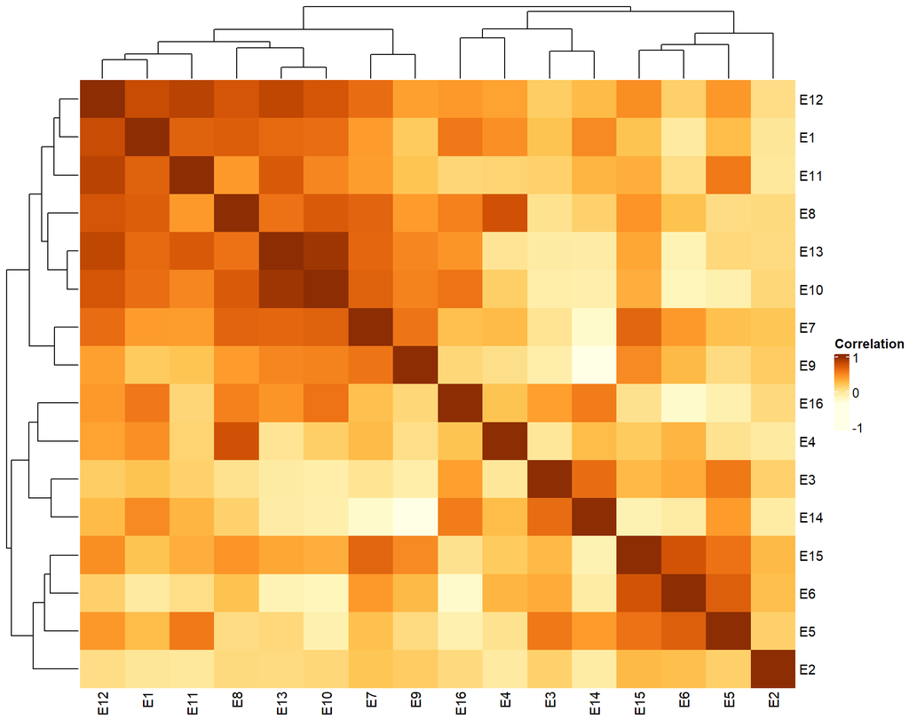

```r
rownames(gencov) = colnames(gencov) = name.env

corr = cov2cor(gencov)

Heatmap(corr,col=colorRampPalette(brewer.pal(8, "YlOrBr"))(25),
        column_dend_height = unit(2, "cm"),
        clustering_method_rows = "complete",
        row_dend_width = unit(2, "cm"),
        clustering_method_columns = "complete",
        heatmap_legend_param = list(title="Correlation",
                                    at=c(-1,0,1),labels=c("-1","0","1")),
        row_names_gp = gpar(fontsize = 11),
        column_names_gp = gpar(fontsize = 11))
```

### Obtenção dos EBLUPs

#### Vetor de escores fatoriais

```r
coef5 = summary(m5,coef = T)$coef.random

fa1.scores = coef5[grep("Comp1",row.names(coef5)),1];
names(fa1.scores) = sub("fa(env, 4)_Comp1:gen_","",names(fa1.scores),fixed=T)
fa2.scores = coef5[grep("Comp2",row.names(coef5)),1];
names(fa2.scores) = sub("fa(env, 4)_Comp2:gen_","",names(fa2.scores),fixed=T)
fa3.scores = coef5[grep("Comp3",row.names(coef5)),1];
names(fa3.scores) = sub("fa(env, 4)_Comp3:gen_","",names(fa3.scores),fixed=T)
fa4.scores = coef5[grep("Comp4",row.names(coef5)),1];
names(fa4.scores) = sub("fa(env, 4)_Comp4:gen_","",names(fa4.scores),fixed=T)
fa5.scores = coef5[grep("Comp4",row.names(coef5)),1];
names(fa5.scores) = sub("fa(env, 4)_Comp4:gen_","",names(fa5.scores),fixed=T)

fa.scores = rbind(as.matrix(fa1.scores),as.matrix(fa2.scores),as.matrix(fa3.scores),
                  as.matrix(fa4.scores),as.matrix(fa5.scores))
```

$$\boldsymbol f = \begin{bmatrix}
2.003 \\
-0.933 \\
-0.759 \\
0.071 \\
0.041 \\
-0.31 \\
-1.387 \\
0.03 \\
0.58 \\
-0.519 \\
-1.261 \\
\vdots \\
-2.245 \\
\end{bmatrix}$$

#### Rotação do vetor de escores fatoriais

```r
fa.scores.star = -kronecker(t(svdmat$v), diag(num.gen))%*%fa.scores
rownames(fa.scores.star) = rep(name.gen,5)

fa1.scores.star = fa.scores.star[1:num.gen,1]
fa2.scores.star = fa.scores.star[(num.gen+1):(num.gen*2),1]
fa3.scores.star = fa.scores.star[(num.gen*2+1):(num.gen*3),1]
fa4.scores.star = fa.scores.star[(num.gen*3+1):(num.gen*4),1]
fa5.scores.star = fa.scores.star[(num.gen*4+1):(num.gen*5),1]
```

$$\boldsymbol f^* = \begin{bmatrix}
1.846 \\
-1.503 \\
-0.679 \\
0.238 \\
0.895 \\
-0.319 \\
-1.288 \\
-0.023 \\
0.503 \\
-0.137 \\
-1.386 \\
\vdots \\
-1.922 \\
\end{bmatrix}$$

#### EBLUPs marginais

```r
EBLUPs_marg = (kronecker(mat.loadings5.star,diag(num.gen))) %*% fa.scores.star
EBLUPs_marg = data.frame("Environment" = rep(name.env,each = num.gen),
                         "Gen" = rep(name.gen,num.env),
                         "EBLUP_marg" = EBLUPs_marg);EBLUPs_marg %>%
  kbl(escape = F, align = 'c',col.names = c("Ambiente","Genótipo","EBLUP marginal")) %>%
  kable_paper("hover",full_width = T, position="center", fixed_thead = T) %>%
  scroll_box(height = "500px")
```

| Ambiente | Genótipo | EBLUP marginal |
| --- | --- | --- |
| E1 | G1 | 1.3996884 |
| E1 | G10 | -0.6518327 |
| E1 | G11 | -0.5303243 |
| E1 | G12 | 0.0492859 |
| E1 | G13 | 0.0284705 |
| E1 | G14 | -0.2163158 |
| E1 | G15 | -0.9691031 |
| E1 | G16 | 0.0211233 |
| E1 | G17 | 0.4050405 |
| E1 | G18 | -0.3625728 |
| E1 | G19 | -0.8812530 |
| E1 | G2 | 0.4940655 |
| E1 | G20 | -0.5539999 |
| E1 | G21 | -0.1857071 |
| E1 | G22 | 0.4760912 |
| E1 | G23 | 0.0120826 |
| E1 | G24 | 0.7052256 |
| E1 | G25 | -0.1202185 |
| E1 | G26 | 0.3272660 |
| E1 | G27 | 0.3794431 |
| E1 | G28 | -0.9629447 |
| E1 | G29 | 1.2613137 |
| E1 | G3 | 0.2704993 |
| E1 | G30 | 0.6433885 |
| E1 | G31 | -1.2631500 |
| E1 | G32 | 0.2242625 |
| E1 | G33 | -1.5136275 |
| E1 | G34 | 0.0926427 |
| E1 | G35 | 0.1124939 |
| E1 | G36 | 0.4976676 |

[output cut: 546 more lines]

### Regressões latentes

```r
EBLUPs_marg$FL_1 = rep(mat.loadings5.star[,1], each = num.gen)
ggplot(subset(EBLUPs_marg, Gen %in% c("G9","G32","G20","G23")),
       aes(x=FL_1,y=EBLUP_marg,colour=Gen))+
  geom_smooth(aes(x=FL_1,y=EBLUP_marg),method=lm, fill = NA)+
  facet_wrap(~Gen, ncol = 4, as.table = T, dir = 'v', scales = 'free_x')+
  geom_vline(xintercept = mean(mat.loadings5.star[,1]),linetype="dashed") +
  geom_point()+
  xlab("Cargas do primeiro fator")+ylab("EBLUP")+
  labs(color = "Genótipo", title = "EBLUP x Cargas do primeiro fator")
```

[figure not shown]

```r
EBLUPs_marg$EBLUPs_marg_f2 = EBLUPs_marg$EBLUP_marg -
  (kronecker(mat.loadings5.star[,1],diag(num.gen))) %*%
  as.matrix(fa1.scores.star)
EBLUPs_marg$FL_2 = rep(mat.loadings5.star[,2], each = num.gen)

ggplot(subset(EBLUPs_marg, Gen %in% c("G9","G32","G20","G23")),
       aes(x=FL_2,y=EBLUPs_marg_f2,colour=Gen))+
  geom_smooth(aes(x=FL_2,y=EBLUPs_marg_f2),method=lm, fill = NA)+
  facet_wrap(~Gen, ncol = 4, as.table = T, dir = 'v', scales = 'free_x')+
  geom_vline(xintercept = mean(mat.loadings5.star[,1]),linetype="dashed") +
  geom_point()+
  xlab("Cargas do segundo fator")+
  ylab(expression(EBLUP[m] - lambda[1]^'*' * f[1]^'*'))+
  labs(color = "Genótipo", title = "EBLUP x Cargas do segundo fator")
```

[figure not shown]

```r
EBLUPs_marg$EBLUPs_marg_f3 = EBLUPs_marg$EBLUP_marg -
  ((kronecker(mat.loadings5.star[,1],diag(num.gen)))
   %*% as.matrix(fa1.scores.star)+
     (kronecker(mat.loadings5.star[,2],diag(num.gen)))
   %*% as.matrix(fa2.scores.star))
EBLUPs_marg$FL_3 = rep(mat.loadings5.star[,3], each = num.gen)

ggplot(subset(EBLUPs_marg, Gen %in% c("G9","G32","G20","G23")),
       aes(x=FL_3,y=EBLUPs_marg_f3,colour=Gen))+
  geom_smooth(aes(x=FL_3,y=EBLUPs_marg_f3),method=lm, fill = NA)+
  facet_wrap(~Gen, ncol = 4, as.table = T, dir = 'v', scales = 'free_x')+
  geom_vline(xintercept = mean(mat.loadings5.star[,3]),linetype="dashed") +
  geom_point()+
  xlab("Cargas do terceiro fator")+
  ylab(expression(EBLUP[m] - (lambda[1]^'*' * f[1]^'*' +
                                lambda[2]^'*' * f[2]^'*')))+
  labs(color = "Genótipo",title = "EBLUP x Cargas do terceiro fator")
```

[figure not shown]

```r
EBLUPs_marg$EBLUPs_marg_f4 = EBLUPs_marg$EBLUP_marg -
  ((kronecker(mat.loadings5.star[,1],diag(num.gen)))
   %*% as.matrix(fa1.scores.star)+
     (kronecker(mat.loadings5.star[,2],diag(num.gen)))
   %*% as.matrix(fa2.scores.star) +
     (kronecker(mat.loadings5.star[,3],diag(num.gen)))
   %*% as.matrix(fa3.scores.star))
EBLUPs_marg$FL_4 = rep(mat.loadings5.star[,4], each = num.gen)

ggplot(subset(EBLUPs_marg, Gen %in% c("G9","G32","G20","G23")),
       aes(x=FL_4,y=EBLUPs_marg_f4,colour=Gen))+
  geom_smooth(aes(x=FL_4,y=EBLUPs_marg_f4),method=lm, fill = NA)+
  facet_wrap(~Gen, ncol = 4, as.table = T, dir = 'v', scales = 'free_x')+
  geom_vline(xintercept = mean(mat.loadings5.star[,3]),linetype="dashed") +
  geom_point()+
  xlab("Cargas do quarto fator")+
  ylab(expression(EBLUP[m] - (lambda[1]^'*' * f[1]^'*' +
lambda[2]^'*' * f[2]^'*' + lambda[3]^'*' * f[3]^'*')))+
  labs(color = "Genótipo",title = "EBLUP x Cargas do quarto fator")
```

[figure not shown]

```r
EBLUPs_marg$EBLUPs_marg_f5 = EBLUPs_marg$EBLUP_marg -
  ((kronecker(mat.loadings5.star[,1],diag(num.gen))) %*%
     as.matrix(fa1.scores.star)+
     (kronecker(mat.loadings5.star[,2],diag(num.gen))) %*%
     as.matrix(fa2.scores.star) +
     (kronecker(mat.loadings5.star[,3],diag(num.gen))) %*%
     as.matrix(fa3.scores.star) +
     (kronecker(mat.loadings5.star[,4],diag(num.gen))) %*%
     as.matrix(fa4.scores.star))
EBLUPs_marg$FL_5 = rep(mat.loadings5.star[,5], each = num.gen)

ggplot(subset(EBLUPs_marg, Gen %in% c("G9","G32","G20","G23")),
       aes(x=FL_5,y=EBLUPs_marg_f5,colour=Gen))+
  geom_smooth(aes(x=FL_5,y=EBLUPs_marg_f5),method=lm, fill = NA)+
  facet_wrap(~Gen, ncol = 4, as.table = T, dir = 'v', scales = 'free_x')+
  geom_vline(xintercept = mean(mat.loadings5.star[,3]),linetype="dashed") +
  geom_point()+
  xlab("Cargas do quinto fator")+
  ylab(expression(EBLUP[m] - (lambda[1]^'*' * f[1]^'*' +
lambda[2]^'*' * f[2]^'*' + lambda[3]^'*' * f[3]^'*' +
  lambda[4]^'*' * f[4]^'*')))+
  labs(color = "Genótipo",title = "EBLUP x Cargas do quinto fator")
```

[figure not shown]

### Ferramentas de seleção

#### Performance geral x Estabilidade

Os limites para seleção dos genótipos ficam a critério do melhorista. Neste exemplo, nosso interesse foi selecionar os cinco melhores. Portanto, definimos que fossem destacados os genótipos com a PG maior ou igual a 0.25 e a ST menor ou igual a 0.5

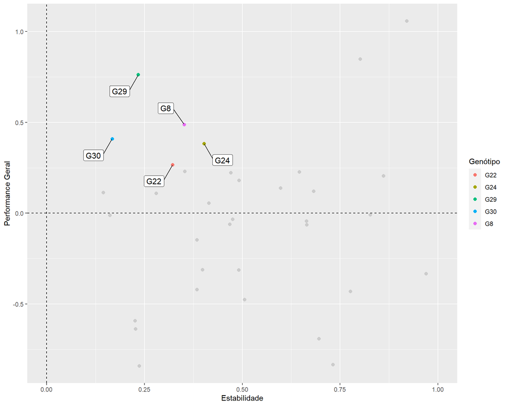

```r
PG = mean(mat.loadings5.star[,1]) * as.matrix(fa1.scores.star)
rest = (EBLUPs_marg$EBLUP_marg -
          (kronecker(mat.loadings5.star[,1],diag(num.gen))) %*%
          fa1.scores.star)^2
STA = data.frame("gen" = rep(name.gen, num.env),
                 "ST" = rest)
STA = STA %>% group_by(gen) %>% summarise(ST = sqrt(mean(ST)))
plot1 = data.frame("gen"=name.gen,
                   "PG" = PG,
                   "ST" = STA$ST)

ggplot(data=plot1)+
  geom_point(aes(x = ST, y = PG, color=gen),size=2)+
  geom_vline(xintercept = 0,linetype="dashed", colour = "black")+
  geom_hline(yintercept = 0,linetype="dashed")+
  scale_x_continuous(name = "Estabilidade", limits = c(0,1))+
  ylab("Performance Geral") +
   gghighlight(max(ST)<=0.50,max(PG)>=0.25,use_direct_label = F)+
  geom_label_repel(aes(x = ST, y = PG, label = gen), size = 4, box.padding = 1)+
  labs(color = "Genótipo")
```

#### Performance geral x Responsividade aos fatores

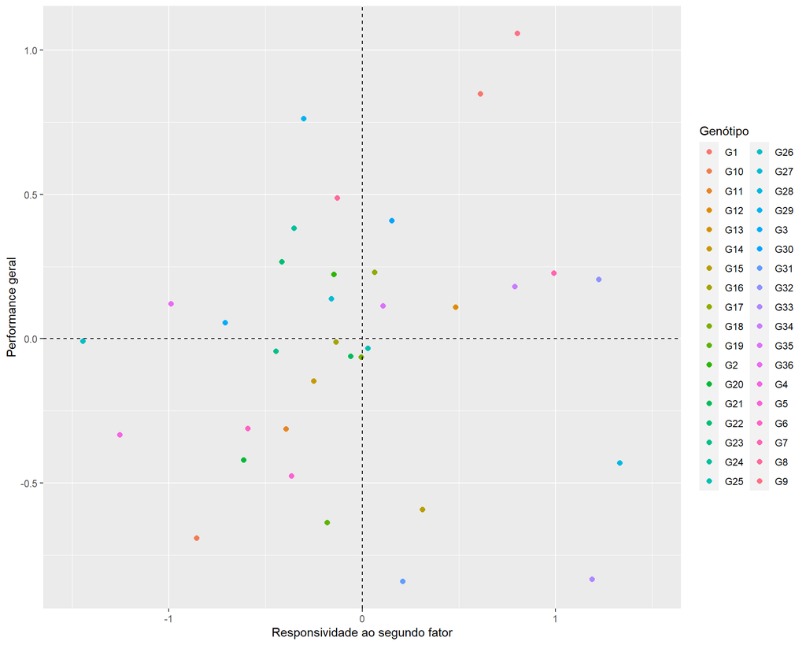

```r
mat.loadings5.star.df = as.data.frame(mat.loadings5.star)

colnames(mat.loadings5.star.df) = c("fa1.loadings","fa2.loadings","fa3.loadings",
                                    "fa4.loadings","fa5.loadings")

fa2.mednegload = mean(mat.loadings5.star.df[mat.loadings5.star.df$fa2.loadings <0,]$fa2.loadings)
fa3.mednegload = mean(mat.loadings5.star.df[mat.loadings5.star.df$fa3.loadings <0,]$fa3.loadings)
fa4.mednegload = mean(mat.loadings5.star.df[mat.loadings5.star.df$fa4.loadings <0,]$fa4.loadings)
fa5.mednegload = mean(mat.loadings5.star.df[mat.loadings5.star.df$fa5.loadings <0,]$fa5.loadings)

fa2.medposload = mean(mat.loadings5.star.df[mat.loadings5.star.df$fa2.loadings >0,]$fa2.loadings)
fa3.medposload = mean(mat.loadings5.star.df[mat.loadings5.star.df$fa3.loadings >0,]$fa3.loadings)
fa4.medposload = mean(mat.loadings5.star.df[mat.loadings5.star.df$fa4.loadings >0,]$fa4.loadings)
fa5.medposload = mean(mat.loadings5.star.df[mat.loadings5.star.df$fa5.loadings >0,]$fa5.loadings)


respfa2 = (fa2.medposload-fa2.mednegload)*fa2.scores.star
respfa3 = (fa3.medposload-fa3.mednegload)*fa3.scores.star
respfa4 = (fa4.medposload-fa4.mednegload)*fa4.scores.star
respfa5 = (fa5.medposload-fa5.mednegload)*fa5.scores.star


plot2 = data.frame("gen" = name.gen,
                   "PG" = PG,
                   "respfa2" = respfa2,
                   "respfa3" = respfa3,
                   "respfa4" = respfa4,
                   "respfa5" = respfa5)

ggplot(data=plot2)+
  geom_point(aes(x = respfa2, y = PG, color=gen),size=2)+
  geom_vline(xintercept = 0,linetype="dashed", colour = "black")+
  geom_hline(yintercept = 0,linetype="dashed")+
  ylab("Performance geral") +
  scale_x_continuous(name = "Responsividade ao segundo fator",
                     limits = c(-1.5,1.5))+
  labs(color = "Genótipo")
```

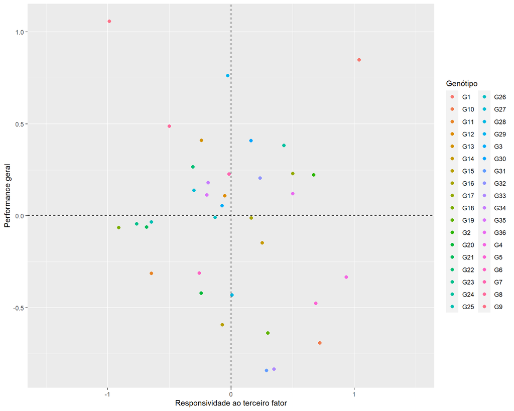

```r
ggplot(data=plot2)+
  geom_point(aes(x = respfa3, y = PG, color=gen),size=2)+
  geom_vline(xintercept = 0,linetype="dashed", colour = "black")+
  geom_hline(yintercept = 0,linetype="dashed")+
  ylab("Performance geral") +
  scale_x_continuous(name = "Responsividade ao terceiro fator",
                     limits = c(-1.5,1.5))+
  labs(color = "Genótipo")
```

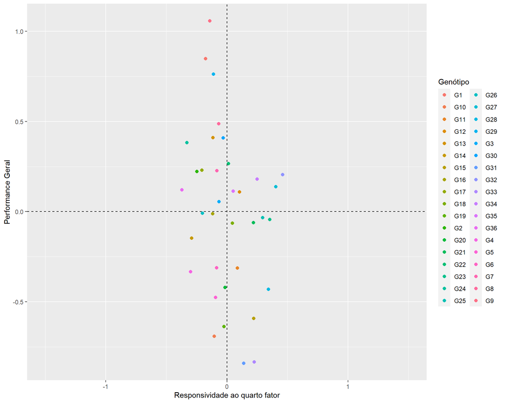

```r
ggplot(data=plot2)+
  geom_point(aes(x = respfa4, y = PG, color=gen),size=2)+
  geom_vline(xintercept = 0,linetype="dashed", colour = "black")+
  geom_hline(yintercept = 0,linetype="dashed")+
  ylab("Performance Geral") +
  scale_x_continuous(name = "Responsividade ao quarto fator",
                     limits = c(-1.5,1.5))+
  labs(color = "Genótipo")
```

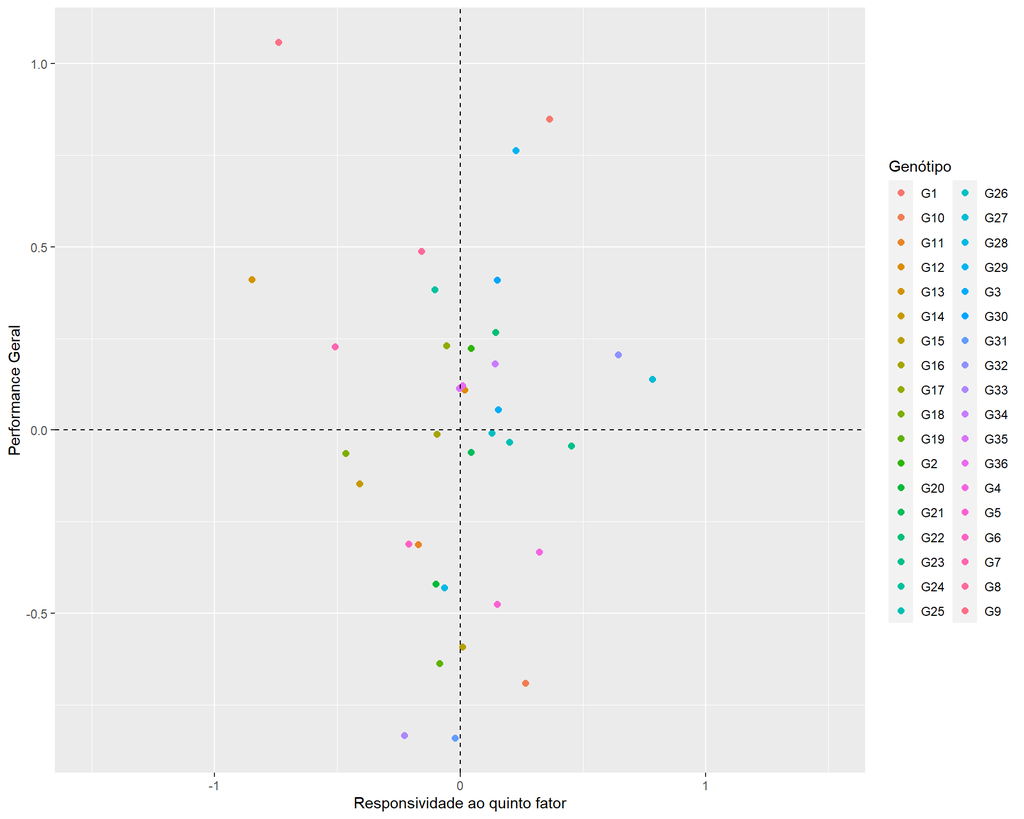

```r
ggplot(data=plot2)+
  geom_point(aes(x = respfa5, y = PG, color=gen),size=2)+
  geom_vline(xintercept = 0,linetype="dashed", colour = "black")+
  geom_hline(yintercept = 0,linetype="dashed")+
  ylab("Performance Geral") +
  scale_x_continuous(name = "Responsividade ao quinto fator",
                     limits = c(-1.5,1.5))+
  labs(color = "Genótipo")
```

# 3. Análise espacial

## Carregando o conjunto de dados

Para realizar as análises individuais, utilizaremos o conjunto de dados entitulado “espacial.csv”

```r
data_esp = read.csv("espacial.csv", header = T,sep=";")

data_esp$Variety = as.factor(data_esp$Variety)
data_esp$Block = as.factor(data_esp$Block)
data_esp$Row = as.factor(data_esp$Row)
data_esp$Col= as.factor(data_esp$Col)
```

## Carregando a função para calcular o AIC ajustado ($AIC_c$)

Esta função foi contruída por [Verbyla (2018)](https://doi.org/10.1111/anzs.12254)

```r
icREML <- function(fm, scale=1) {
    if(!is.list(fm)) stop(" Models need to be in a list\n")
    if(is.null(names(fm))) namesfm <- paste("fm", 1:length(fm))
    else namesfm <- names(fm)
    require(asreml)
    asreml.options(Cfixed = TRUE, gammaPar=FALSE)
    fm <- lapply(fm, function(el) {
        if(is.null(el$Cfixed)) {
            out <- update(el, maxit=1) }
        else out <- el
        out})
    logl <- lapply(fm, function(el) el$loglik)
    summ <- lapply(fm, function(el) summary(el, coef=TRUE)$coef.fixed)
    which.X0 <- lapply(summ, function(el) !is.na(el[, "z.ratio"]))
    p.0 <- lapply(which.X0, function(el) sum(el))
    Cfixed <- lapply(fm, function(el) el$Cfixed)
    logdet <- lapply(1:length(fm), function(el, Cfixed, which.X0, scale) {
        log(prod(svd(as.matrix(scale*Cfixed[[el]][which.X0[[el]], which.X0[[el]]]))$d))
    }, Cfixed, which.X0, scale)
    vparam <- lapply(fm, function(el) summary(el)$varcomp)
    q.0 <- lapply(vparam, function(el) sum(!(el$bound == "F" | el$bound == "B")))
    b.0 <- lapply(vparam, function(el) sum(el$bound == "F" | el$bound == "B"))
    logl <- lapply(1:length(fm), function(el, logl, logdet, p.0) {
        logl[[el]] - logdet[[el]]/2}, logl, logdet,p.0)
    aic <- unlist(lapply(1:length(fm), function(el, logl, p.0, q.0) {
        -2*logl[[el]] + 2*(p.0[[el]] + q.0[[el]])}, logl, p.0, q.0))
    bic <- unlist(lapply(1:length(fm), function(el, logl, p.0, q.0, fm) {
        -2*logl[[el]] + log(fm[[el]]$nedf+p.0[[el]])*(p.0[[el]] + q.0[[el]])},
        logl, p.0, q.0, fm))
    results <- data.frame(model=namesfm, loglik = unlist(logl), p=unlist(p.0),
                          q=unlist(q.0), b = unlist(b.0), AIC = aic, BIC = bic, logdet=unlist(logdet))
    row.names(results) <- 1:dim(results)[1]
    invisible(results)
}
```

## Modelo 1: Sem ajuste espacial

```r
m1 <- asreml(yield ~ 1,
              random = ~ Variety + Block,
              data = data_esp)
```

```
## Model fitted using the gamma parameterization.
## ASReml 4.1.0 Thu Sep 15 22:01:35 2022
##           LogLik        Sigma2     DF     wall    cpu
##  1     -1759.407      14419.82    329 22:01:35    0.0
##  2     -1757.715      14101.21    329 22:01:35    0.0
##  3     -1755.926      13741.09    329 22:01:35    0.0
##  4     -1754.746      13506.11    329 22:01:35    0.0
##  5     -1754.150      13385.21    329 22:01:35    0.0
##  6     -1754.000      13345.37    329 22:01:35    0.0
##  7     -1753.982      13331.28    329 22:01:35    0.0
##  8     -1753.982      13328.98    329 22:01:35    0.0
```

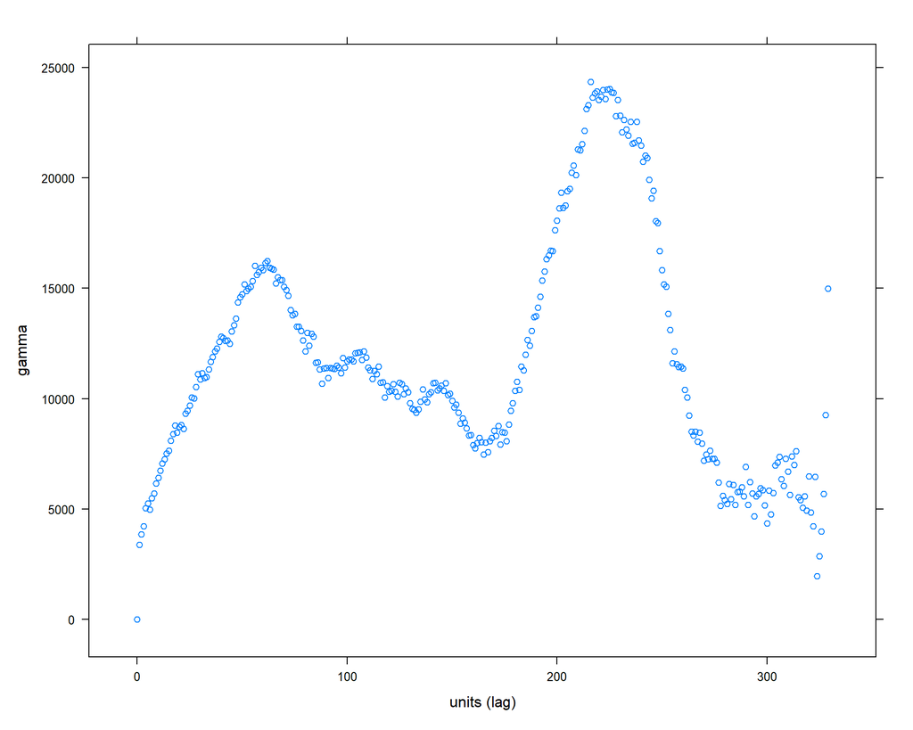

```r
plot(varioGram(m1))
```

## Modelo 2: Auto-regressivo

```r
m2 <- asreml(yield ~ 1,
              random = ~ Variety + Block,
              residual = ~ ar1(Col):ar1(Row),
              data = data_esp)
```

```
## Model fitted using the gamma parameterization.
## ASReml 4.1.0 Thu Sep 15 22:01:35 2022
##           LogLik        Sigma2     DF     wall    cpu
##  1     -1733.826      12580.63    329 22:01:35    0.0 (1 restrained)
##  2     -1669.961       9508.85    329 22:01:35    0.0
##  3     -1617.385       8255.14    329 22:01:35    0.0
##  4     -1601.201       9579.12    329 22:01:35    0.0
##  5     -1596.617      12113.38    329 22:01:35    0.0
##  6     -1596.051      13525.06    329 22:01:35    0.0
##  7     -1595.988      14116.27    329 22:01:35    0.0
##  8     -1595.981      14330.14    329 22:01:35    0.0
##  9     -1595.980      14403.23    329 22:01:35    0.0
```

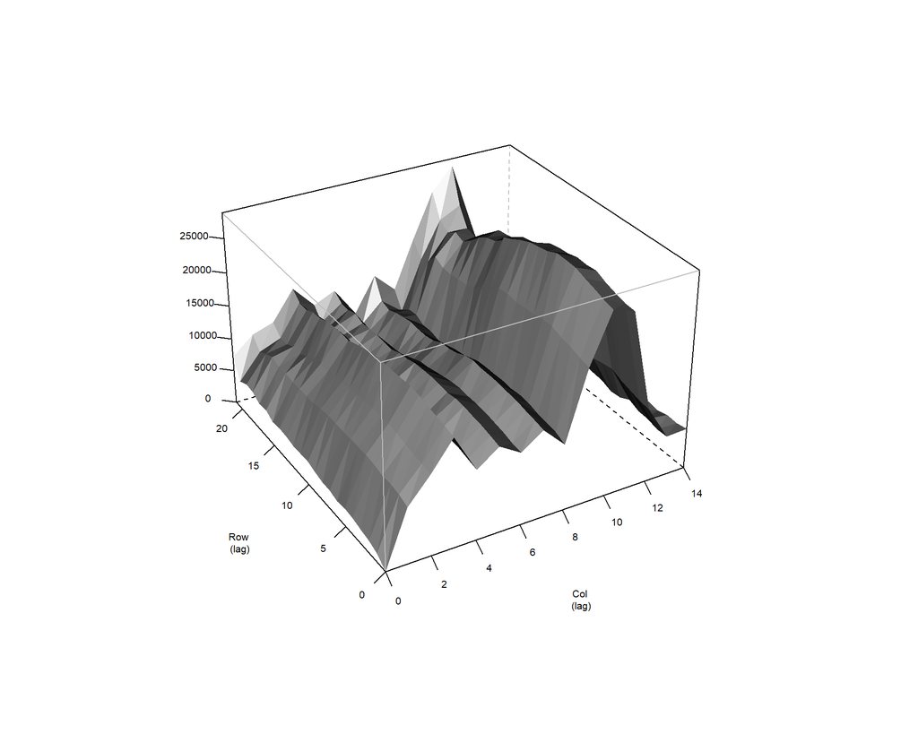

```r
plot(varioGram(m2))
```

## Modelo 3: Auto-regressivo + Pepita

```r
m3 <- asreml(yield ~ 1,
              random = ~ Variety + Block + units,
              residual = ~ ar1(Col):ar1(Row),
              data = data_esp)
```

```
## Model fitted using the gamma parameterization.
## ASReml 4.1.0 Thu Sep 15 22:01:36 2022
##           LogLik        Sigma2     DF     wall    cpu
##  1     -1736.552      11681.29    329 22:01:36    0.0
##  2     -1706.200       5103.51    329 22:01:36    0.0 (1 restrained)
##  3     -1623.773       8425.35    329 22:01:36    0.0 (1 restrained)
##  4     -1583.800       6988.33    329 22:01:36    0.0 (1 restrained)
##  5     -1570.095       7410.42    329 22:01:36    0.0 (1 restrained)
##  6     -1565.509      17054.33    329 22:01:36    0.0
##  7     -1564.713      17486.14    329 22:01:36    0.0
##  8     -1564.520      19816.65    329 22:01:36    0.0
##  9     -1564.467      20811.71    329 22:01:36    0.0
## 10     -1564.452      21432.42    329 22:01:36    0.0
## 11     -1564.449      21745.41    329 22:01:36    0.0
## 12     -1564.448      21905.70    329 22:01:36    0.0
## 13     -1564.447      21985.94    329 22:01:36    0.0
```

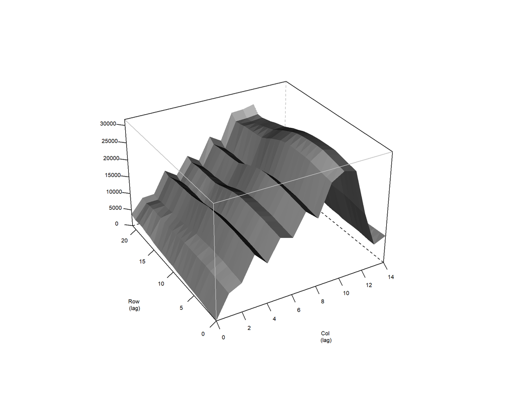

```r
plot(varioGram(m3))
```

## Modelo 4: Anteriores + Aleatório de linha e coluna

```r
m4 <- asreml(yield ~ 1,
              random = ~ Variety + Block + Row + Col + units,
              residual = ~ ar1(Col):ar1(Row),
              data = data_esp)
```

```
## Model fitted using the gamma parameterization.
## ASReml 4.1.0 Thu Sep 15 22:01:37 2022
##           LogLik        Sigma2     DF     wall    cpu
##  1     -1671.318      7224.596    329 22:01:37    0.0
##  2     -1650.323      4153.455    329 22:01:37    0.0 (2 restrained)
##  3     -1603.162      2992.391    329 22:01:37    0.0 (1 restrained)
##  4     -1575.329      2068.590    329 22:01:37    0.0 (1 restrained)
##  5     -1564.068      2600.891    329 22:01:37    0.0 (6 restrained)
##  6     -1569.079     27749.195    329 22:01:37    0.0 (1 restrained)
##  7     -1562.548     18371.564    329 22:01:37    0.0 (1 restrained)
##  8     -1560.267     12975.963    329 22:01:37    0.0
##  9     -1559.832     10683.326    329 22:01:37    0.0
## 10     -1559.824     10696.262    329 22:01:37    0.0
## 11     -1559.824     10714.842    329 22:01:37    0.0
```

```r
m4 <- update(m4)
```

```
## Model fitted using the gamma parameterization.
## ASReml 4.1.0 Thu Sep 15 22:01:38 2022
##           LogLik        Sigma2     DF     wall    cpu
##  1     -1559.824      10718.86    329 22:01:38    0.1
##  2     -1559.824      10719.23    329 22:01:38    0.0
```

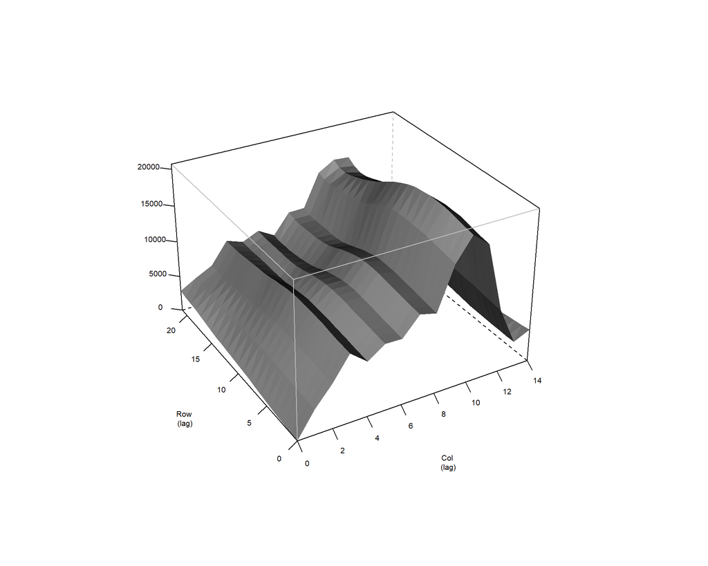

```r
plot(varioGram(m4))
```

## Modelo 5: Anteriores + Efeito linear fixo de linha e coluna

```r
m5 <- asreml(yield ~ lin(Row) + lin(Col),
              random = ~ Variety + Block + Row + Col + units,
              residual = ~ ar1(Col):ar1(Row),
              data = data_esp)
```

```
## Model fitted using the gamma parameterization.
## ASReml 4.1.0 Thu Sep 15 22:01:38 2022
##           LogLik        Sigma2     DF     wall    cpu
##  1     -1663.625      7000.845    327 22:01:38    0.0
##  2     -1642.771      4087.477    327 22:01:38    0.0 (2 restrained)
##  3     -1598.696      2819.293    327 22:01:38    0.1 (1 restrained)
##  4     -1570.582      1932.493    327 22:01:38    0.0 (1 restrained)
##  5     -1559.324      2336.948    327 22:01:39    0.1 (6 restrained)
##  6     -1563.788     25206.783    327 22:01:39    0.1 (1 restrained)
##  7     -1557.628     17133.883    327 22:01:39    0.0 (1 restrained)
##  8     -1555.542     12206.958    327 22:01:39    0.0
##  9     -1555.144     10046.319    327 22:01:39    0.0
## 10     -1555.138     10034.896    327 22:01:39    0.0
```

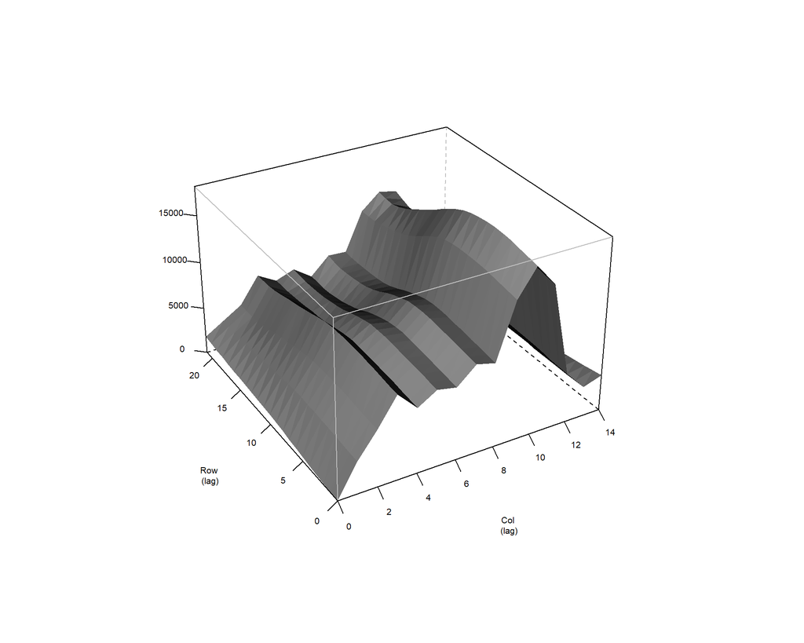

```r
plot(varioGram(m5))
```

## Modelo 6: Anteriores + Spline no sentido da coluna

```r
m6 <- asreml(yield ~ lin(Row) + lin(Col),
              random = ~ Variety + Block + Row + Col + spl(col) + units,
              residual = ~ ar1(Col):ar1(Row),
              data = data_esp)
```

```
## Model fitted using the gamma parameterization.
## ASReml 4.1.0 Thu Sep 15 22:01:39 2022
## Spline: design points closer than 0.0014 have been merged.
##           LogLik        Sigma2     DF     wall    cpu
##  1     -1613.452      5087.717    327 22:01:39    0.1
##  2     -1601.388      3169.909    327 22:01:40    0.1 (3 restrained)
##  3     -1578.675      2181.500    327 22:01:40    0.1 (2 restrained)
##  4     -1558.494      1661.957    327 22:01:40    0.1 (2 restrained)
##  5     -1553.107      2055.506    327 22:01:40    0.1 (1 restrained)
##  6     -1551.973      3062.809    327 22:01:40    0.1
##  7     -1551.903      3195.873    327 22:01:40    0.0
##  8     -1551.894      3191.642    327 22:01:40    0.1
##  9     -1551.893      3136.080    327 22:01:40    0.1
```

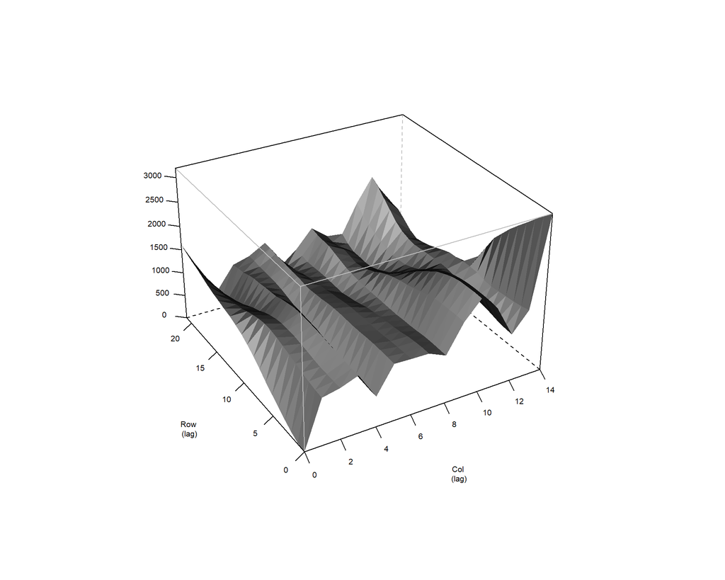

```r
plot(varioGram(m6))
```

## $AIC_c$

```r
mods = list(m1=m1, m2=m2, m3=m3, m4=m4, m5=m5, m6=m6)

selection <- icREML(mods)
```

```
## Model fitted using the gamma parameterization.
## ASReml 4.1.0 Thu Sep 15 22:01:41 2022
##           LogLik        Sigma2     DF     wall    cpu
##  1     -1753.982      13328.91    329 22:01:41    0.0
## Model fitted using the gamma parameterization.
## ASReml 4.1.0 Thu Sep 15 22:01:41 2022
##           LogLik        Sigma2     DF     wall    cpu
##  1     -1595.980      14427.88    329 22:01:41    0.0
## Model fitted using the gamma parameterization.
## ASReml 4.1.0 Thu Sep 15 22:01:41 2022
##           LogLik        Sigma2     DF     wall    cpu
##  1     -1564.447      22025.96    329 22:01:41    0.0
## Model fitted using the gamma parameterization.
## ASReml 4.1.0 Thu Sep 15 22:01:41 2022
##           LogLik        Sigma2     DF     wall    cpu
##  1     -1559.824      10720.13    329 22:01:41    0.0
## Model fitted using the gamma parameterization.
## ASReml 4.1.0 Thu Sep 15 22:01:41 2022
##           LogLik        Sigma2     DF     wall    cpu
##  1     -1555.137      10047.75    327 22:01:42    0.1
## Model fitted using the gamma parameterization.
## ASReml 4.1.0 Thu Sep 15 22:01:42 2022
## Spline: design points closer than 0.0014 have been merged.
##           LogLik        Sigma2     DF     wall    cpu
##  1     -1551.893      3139.793    327 22:01:42    0.1
```

```r
selection
```

```
##   model    loglik p q b      AIC      BIC    logdet
## 1    m1 -1758.165 1 3 0 3524.331 3539.527  8.367356
## 2    m2 -1600.114 1 5 0 3212.229 3235.023  8.268164
## 3    m3 -1568.899 1 5 1 3149.798 3172.592  8.903010
## 4    m4 -1563.932 1 7 1 3143.865 3174.258  8.216938
## 5    m5 -1562.312 3 7 1 3144.624 3182.615 14.349528
## 6    m6 -1556.860 3 8 1 3135.721 3177.511  9.934153
```